# Working with SummarizedExperiment

Originally developed for and specifically tailored to microarray data, the `ExpressionSet` container has several limitations when dealing with other types of genomic high-throughput data. Especially sequencing-based technologies such as RNA-seq require compatibility with operations on genomic regions. On the other hand, big data as e.g. obtained from methylation and single-cell assays requires efficient dealing with out-of-memory representations. These demands led to the development of `SummarizedExperiment`, which has largely replaced `ExpressionSet` as the standard Bioconductor container for genomic high-throughput data.

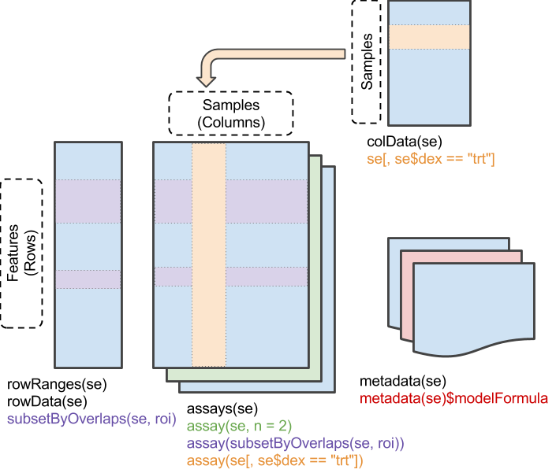

| ExpressionSet | SummarizedExperiment |
| --- | --- |
| `exprs` | `assay` |
| `pData` | `colData` |
| `fData` | `rowData` |
| `experimentData` | `metadata` |
| `annotation` | `metadata(se)$annotation` |

Backward compatibility is provided by seamless conversion of an `ExpressionSet` to a `SummarizedExperiment`,

```r
library(SummarizedExperiment)
se <- as(eset, "SummarizedExperiment")
se
```

```
## class: SummarizedExperiment
## dim: 8793 24
## metadata(3): experimentData annotation protocolData
## assays(1): exprs
## rownames(8793): 1007_s_at 1053_at ... AFFX-r2-P1-cre-3_at
##   AFFX-r2-P1-cre-5_at
## rowData names(4): PROBEID CHR CHRLOC SYMBOL
## colnames(24): GSM136508.CEL.gz GSM136530.CEL.gz ...
##   GSM136564.CEL.gz GSM136572.CEL.gz
## colData names(4): ethnicity date filename group
```

and vice versa.

```r
eset <- as(se, "ExpressionSet")
eset
```

```
## ExpressionSet (storageMode: environment)
## assayData: 8793 features, 24 samples
##   element names: exprs
## protocolData: none
## phenoData
##   sampleNames: GSM136508.CEL.gz GSM136530.CEL.gz ...
##     GSM136572.CEL.gz (24 total)
##   varLabels: ethnicity date filename group
##   varMetadata: labelDescription
## featureData
##   featureNames: 1007_s_at 1053_at ... AFFX-r2-P1-cre-5_at (8793
##     total)
##   fvarLabels: PROBEID CHR CHRLOC SYMBOL
##   fvarMetadata: labelDescription
## experimentData: use 'experimentData(object)'
##   pubMedIds: 17206142
## Annotation: hgfocus
```

## Construction from GEO

The [NCBI Gene Expression Omnibus](https://www.ncbi.nlm.nih.gov/geo) (GEO) serves as a public repository for a wide range of high-throughput experimental data. These data include single and dual channel microarray-based experiments measuring mRNA, genomic DNA, and protein abundance, as well as non-array techniques such as serial analysis of gene expression (SAGE), mass spectrometry proteomic data, and high-throughput sequencing data.

Bioconductor’s GEOquery package simplifies harvesting of this archive, and forms a bridge between GEO and the analysis capabilities in Bioconductor. We use the package to obtain [expression data from a pan-cancer study](https://www.ncbi.nlm.nih.gov/geo/query/acc.cgi?acc=GSE103512) as an `ExpressionSet`.

```r
library(GEOquery)
gse <- getGEO("GSE103512")[[1]]
gse
```

```
## ExpressionSet (storageMode: lockedEnvironment)
## assayData: 54715 features, 280 samples
##   element names: exprs
## protocolData: none
## phenoData
##   sampleNames: GSM2772660 GSM2772661 ... GSM2772939 (280 total)
##   varLabels: title geo_accession ... weight:ch1 (72 total)
##   varMetadata: labelDescription
## featureData
##   featureNames: 1007_PM_s_at 1053_PM_at ... AFFX-TrpnX-M_at (54715
##     total)
##   fvarLabels: ID GB_ACC ... Gene Ontology Molecular Function (16
##     total)
##   fvarMetadata: Column Description labelDescription
## experimentData: use 'experimentData(object)'
##   pubMedIds: 29133367
## Annotation: GPL13158
```

```r
as(gse, "SummarizedExperiment")
```

```
## class: SummarizedExperiment
## dim: 54715 280
## metadata(3): experimentData annotation protocolData
## assays(1): exprs
## rownames(54715): 1007_PM_s_at 1053_PM_at ... AFFX-TrpnX-5_at
##   AFFX-TrpnX-M_at
## rowData names(16): ID GB_ACC ... Gene.Ontology.Cellular.Component
##   Gene.Ontology.Molecular.Function
## colnames(280): GSM2772660 GSM2772661 ... GSM2772938 GSM2772939
## colData names(72): title geo_accession ... tumorsize.ch1
##   weight.ch1
```

## Anatomy of a `SummarizedExperiment`

The *SummarizedExperiment* package contains two classes: `SummarizedExperiment` and `RangedSummarizedExperiment`.

`SummarizedExperiment` is a matrix-like container where rows represent features of interest (e.g. genes, transcripts, exons, etc.) and columns represent samples. The objects contain one or more assays, each represented by a matrix-like object of numeric or other mode. The rows of a `SummarizedExperiment` object represent features of interest. Information about these features is stored in a `DataFrame` object, accessible using the function `rowData()`. Each row of the `DataFrame` provides information on the feature in the corresponding row of the `SummarizedExperiment` object. Columns of the DataFrame represent different attributes of the features of interest, e.g., gene or transcript IDs, etc.

`RangedSummarizedExperiment` is the child of the `SummarizedExperiment` class which means that all the methods on `SummarizedExperiment` also work on a `RangedSummarizedExperiment`.

The fundamental difference between the two classes is that the rows of a `RangedSummarizedExperiment` object represent genomic ranges of interest instead of a `DataFrame` of features. The `RangedSummarizedExperiment` ranges are described by a `GRanges` or a `GRangesList` object, accessible using the `rowRanges()` function.

The `airway` package contains an example dataset from an RNA-Seq experiment of read counts per gene for airway smooth muscles. These data are stored in a `RangedSummarizedExperiment` object which contains 8 different experimental and assays 64,102 gene transcripts.

```r
library(airway)
data(airway)
se <- airway
se
```

```
## class: RangedSummarizedExperiment
## dim: 64102 8
## metadata(1): ''
## assays(1): counts
## rownames(64102): ENSG00000000003 ENSG00000000005 ... LRG_98 LRG_99
## rowData names(0):
## colnames(8): SRR1039508 SRR1039509 ... SRR1039520 SRR1039521
## colData names(9): SampleName cell ... Sample BioSample
```

```r
rowRanges(se)
```

```
## GRangesList object of length 64102:
## $ENSG00000000003
## GRanges object with 17 ranges and 2 metadata columns:
##        seqnames            ranges strand |   exon_id       exon_name
##           <Rle>         <IRanges>  <Rle> | <integer>     <character>
##    [1]        X 99883667-99884983      - |    667145 ENSE00001459322
##    [2]        X 99885756-99885863      - |    667146 ENSE00000868868
##    [3]        X 99887482-99887565      - |    667147 ENSE00000401072
##    [4]        X 99887538-99887565      - |    667148 ENSE00001849132
##    [5]        X 99888402-99888536      - |    667149 ENSE00003554016
##    ...      ...               ...    ... .       ...             ...
##   [13]        X 99890555-99890743      - |    667156 ENSE00003512331
##   [14]        X 99891188-99891686      - |    667158 ENSE00001886883
##   [15]        X 99891605-99891803      - |    667159 ENSE00001855382
##   [16]        X 99891790-99892101      - |    667160 ENSE00001863395
##   [17]        X 99894942-99894988      - |    667161 ENSE00001828996
##   -------
##   seqinfo: 722 sequences (1 circular) from an unspecified genome
##
## ...
## <64101 more elements>
```

### Assays

To retrieve the experiment data from a `SummarizedExperiment` object one can use the `assays()` accessor. An object can have multiple assay datasets each of which can be accessed using the `$` operator. The `airway` dataset contains only one assay (`counts`). Here each row represents a gene transcript and each column one of the samples.

```r
assays(se)
```

```
## List of length 1
## names(1): counts
```

```r
head( assays(se)$counts )
```

```
##                 SRR1039508 SRR1039509 SRR1039512 SRR1039513 SRR1039516
## ENSG00000000003        679        448        873        408       1138
## ENSG00000000005          0          0          0          0          0
## ENSG00000000419        467        515        621        365        587
## ENSG00000000457        260        211        263        164        245
## ENSG00000000460         60         55         40         35         78
## ENSG00000000938          0          0          2          0          1
##                 SRR1039517 SRR1039520 SRR1039521
## ENSG00000000003       1047        770        572
## ENSG00000000005          0          0          0
## ENSG00000000419        799        417        508
## ENSG00000000457        331        233        229
## ENSG00000000460         63         76         60
## ENSG00000000938          0          0          0
```

```r
head( assay(se) )
```

```
##                 SRR1039508 SRR1039509 SRR1039512 SRR1039513 SRR1039516
## ENSG00000000003        679        448        873        408       1138
## ENSG00000000005          0          0          0          0          0
## ENSG00000000419        467        515        621        365        587
## ENSG00000000457        260        211        263        164        245
## ENSG00000000460         60         55         40         35         78
## ENSG00000000938          0          0          2          0          1
##                 SRR1039517 SRR1039520 SRR1039521
## ENSG00000000003       1047        770        572
## ENSG00000000005          0          0          0
## ENSG00000000419        799        417        508
## ENSG00000000457        331        233        229
## ENSG00000000460         63         76         60
## ENSG00000000938          0          0          0
```

There are two accessor functions for extracting the assay data from a `SummarizedExperiment` object. `assays()` operates on the entire list of assay data as a whole, while `assay()` operates on only one assay at a time. `assay(x, i)` is simply a convenience function which is equivalent to `assays(x)[[i]]`. `assay` defaults to the first assay if no `i` is given.

## Common operations on `SummarizedExperiment`

### Subsetting

- `[` Performs two dimensional subsetting, just like subsetting a matrix or data frame.

```r
# subset the first five transcripts and first three samples
se[1:5, 1:3]
```

```
## class: RangedSummarizedExperiment
## dim: 5 3
## metadata(1): ''
## assays(1): counts
## rownames(5): ENSG00000000003 ENSG00000000005 ENSG00000000419
##   ENSG00000000457 ENSG00000000460
## rowData names(0):
## colnames(3): SRR1039508 SRR1039509 SRR1039512
## colData names(9): SampleName cell ... Sample BioSample
```

- `$` operates on `colData()` columns, for easy sample extraction.

```r
se[, se$cell == "N61311"]
```

```
## class: RangedSummarizedExperiment
## dim: 64102 2
## metadata(1): ''
## assays(1): counts
## rownames(64102): ENSG00000000003 ENSG00000000005 ... LRG_98 LRG_99
## rowData names(0):
## colnames(2): SRR1039508 SRR1039509
## colData names(9): SampleName cell ... Sample BioSample
```

### Range-based operations

- `subsetByOverlaps()` `SummarizedExperiment` objects support all of the `findOverlaps()` methods and associated functions. This includes `subsetByOverlaps()`, which makes it easy to subset a `SummarizedExperiment` object by an interval.

```r
# Subset for only rows which are in the interval 100,000 to 110,000 of
# chromosome 1
roi <- GRanges(seqnames="1", ranges=100000:1100000)
subsetByOverlaps(se, roi)
```

```
## class: RangedSummarizedExperiment
## dim: 74 8
## metadata(1): ''
## assays(1): counts
## rownames(74): ENSG00000131591 ENSG00000177757 ... ENSG00000272512
##   ENSG00000273443
## rowData names(0):
## colnames(8): SRR1039508 SRR1039509 ... SRR1039520 SRR1039521
## colData names(9): SampleName cell ... Sample BioSample
```

## Extensions of SummarizedExperiment

- RaggedExperiment
- MultiAssayExperiment
- SingleCellExperiment
- TreeSummarizedExperiment

## Exercises (15 min)

1. Use the `GEOquery` package to download GSE5859 as an `ExpressionSet`, and transform it into a `SummarizedExperiment`.
2. The `rowRanges` of the `airway` dataset are stored in a `GRangesList`, which contains the exon coordinates for each gene. Use the `range` function to determine the region covered by exons for each gene. Use `unlist` on the resulting `GRangesList` to convert it into a `GRanges`, and replace the `rowRanges` of `airway` with it.
3. Add a `colData` column named `GROUP` to the `airway` dataset. This column should be a binary vector which indicates wether the cell lines have been treated with dexamethasone (1) or not (0).